# DATA624_Homework6

John Ferrara

2025-03-15

## 1) Figure 9.32 shows the ACFs for 36 random numbers, 360 random numbers and 1,000 random numbers.

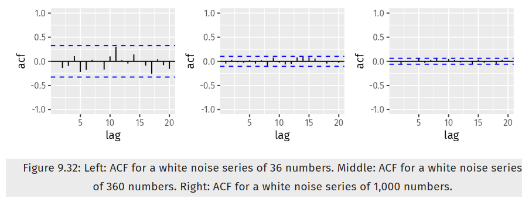

Figure 9.32

#### b) Why are the critical values at different distances from the mean of zero? Why are the autocorrelations different in each figure when they each refer to white noise?

The critical values are at different distances from the mean of zero because of the dataset they are plotted from. Going from left to right, the dataset consisted of 36 random numbers 360 random numbers, and then 1000 random numbers. As the pool of random numbers got larger, the confidence interval where 95% of the data sits got more and more narrow. With a smaller pool of numbers there is the potential for much more variation in the numbers distribution, while larger random numbers would follow more of a normal distribution pattern which would influence the autocorrelation patterns. The autocorrelation patters are different even though they each refer to white noise because the autocorrelation is the numbers within a data set being compared to other numbers in the same data set. So the variations in critical values and auto correlations are going to be different for each grouping of random numbers regardless of whether there is a pattern in the data or not.

## 2) A classic example of a non-stationary series are stock prices. Plot the daily closing prices for Amazon stock (contained in gafa_stock), along with the ACF and PACF. Explain how each plot shows that the series is non-stationary and should be differenced.

```
## Plot variable not specified, automatically selected `.vars = Close`
```

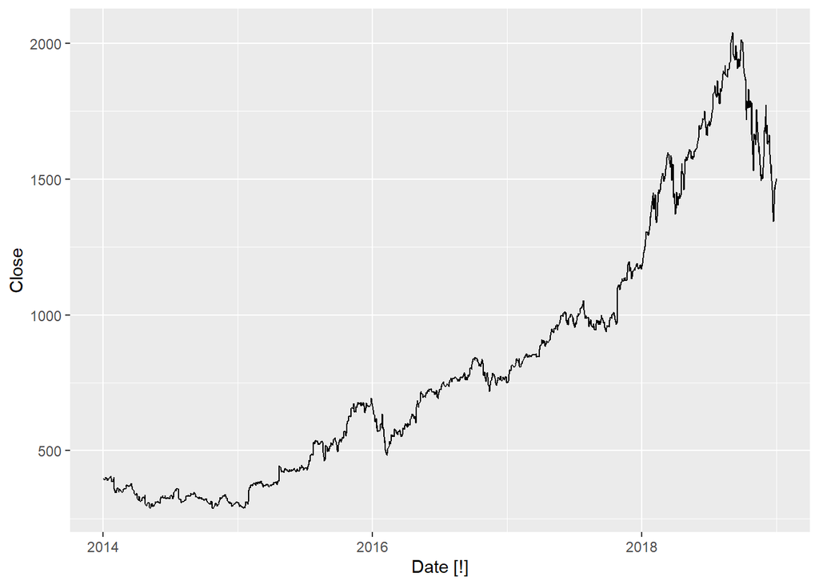

```r
#table with just amazon
amazon <- gafa_stock |> filter(Symbol =='AMZN')|> select(-Open, -High, -Adj_Close, -Low, -Volume)
print(amazon |> autoplot())
```

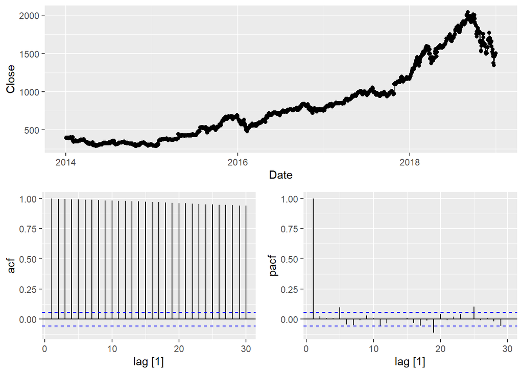

```r
## Here is the ACF and PACF plots for the raw non-differentiated or otherwise transformed data.
print(amazon |> gg_tsdisplay(Close,plot_type ="partial"))
```

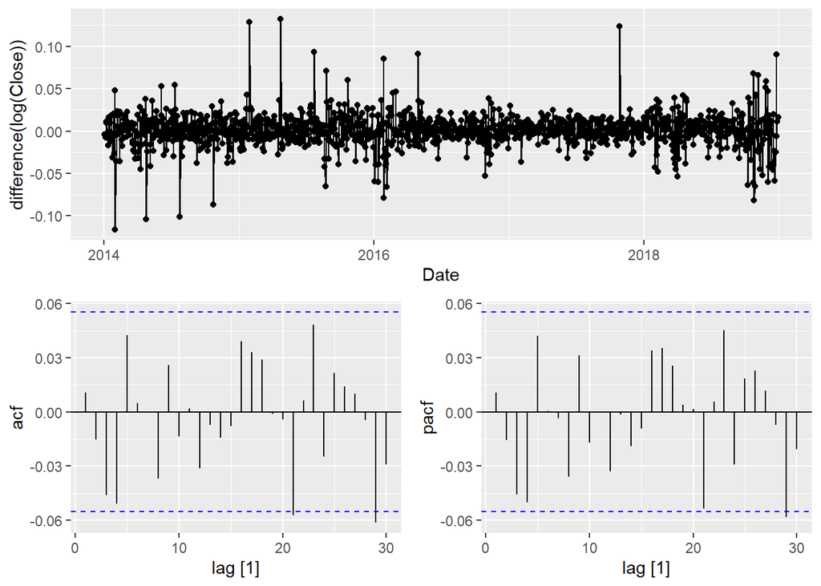

```r
### After looking at these plots, firstly the data is not stationary. According to the first plot, there is a trend in the raw data that needs to be flattened out to have the same type of varying values for different sub time frames in this larger time frame. Additionally, when looking at the ACF chart all of the autocorrelation values start at 1 and slowly decrease just under 1. All of these values are very much so outside of the Confidence interval lines. This means there is a fairly consistent trend in the data, thus not stationary. Lastly, for the PACF chart there is a very large spike value in the beginning of the data,and 2 to 3 smaller spikes that are also outside the confidence interval band. This supports the non-stationary nature of the data.


## No seasonality, but trends present in the close prices of the stock.
print(amazon |> gg_tsdisplay(difference(log(Close)),plot_type ="partial"))
```

```r
# Lastly, you can see here, with the logged and differentiated chart that the data is now stationary. There is no trend in the top chart, which now looks like white noise. The ACF and PACF charts both look much more reasonable with nearly all of the values being within the 95% confidence interval range.
```

## 3) For the following series, find an appropriate Box-Cox transformation and order of differencing in order to obtain stationary data.

#### a) Turkish GDP from global_economy.

```
## Plot variable not specified, automatically selected `.vars = GDP`
```

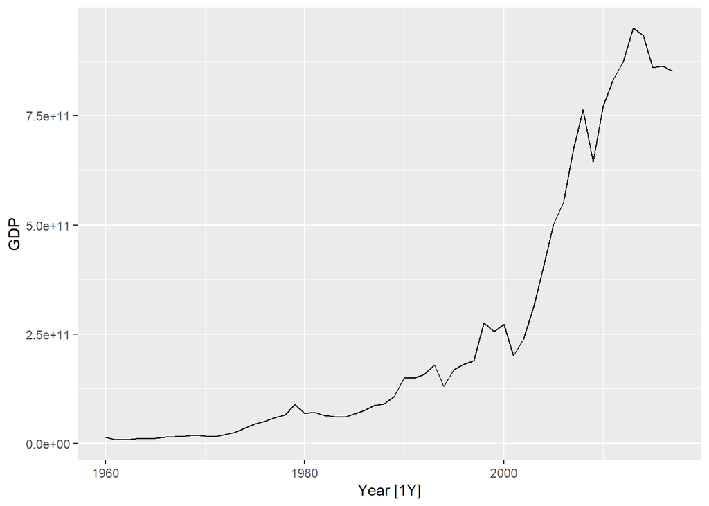

```r
turkey_economy <- global_economy |> filter(Country =='Turkey')

print(turkey_economy|> autoplot())
```

```r
lambda <- turkey_economy |>
  features(GDP, features = guerrero) |>
  pull(lambda_guerrero)
print(lambda) ## 0.157 Close to a log transformation lambda
```

```
## [1] 0.1572187
```

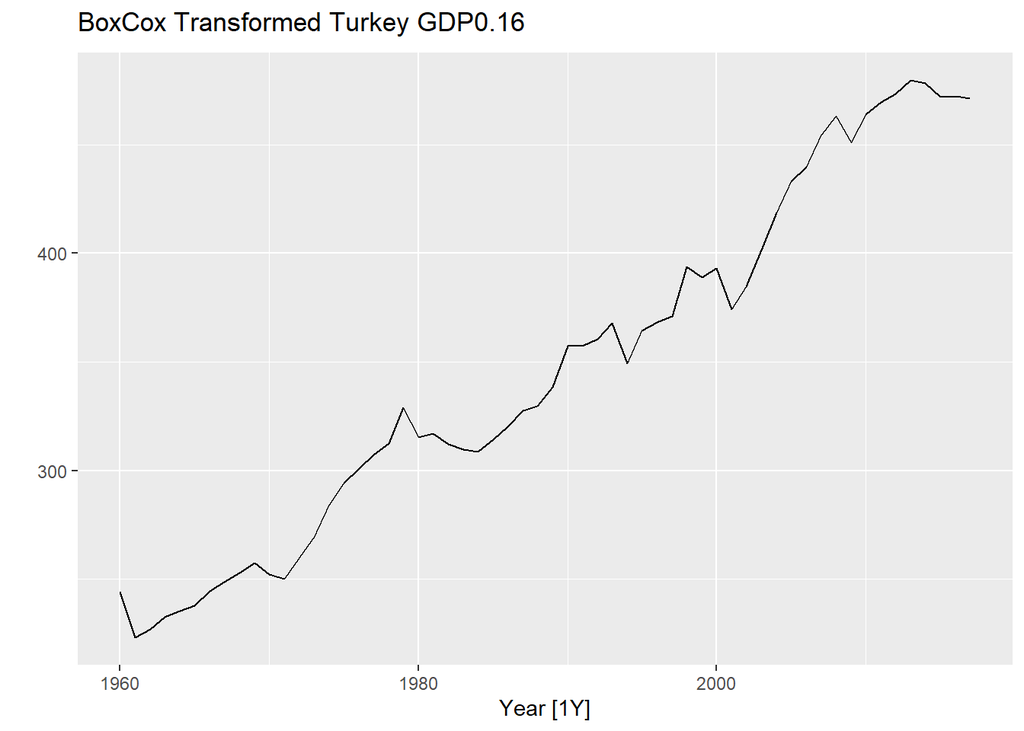

```r
## Box Cox Transform successful now to find the differentiation needs
print(turkey_economy |>  autoplot(box_cox(GDP, lambda)) +  labs(y = "",title = latex2exp::TeX(paste0("BoxCox Transformed Turkey GDP",round(lambda,2)))))
```

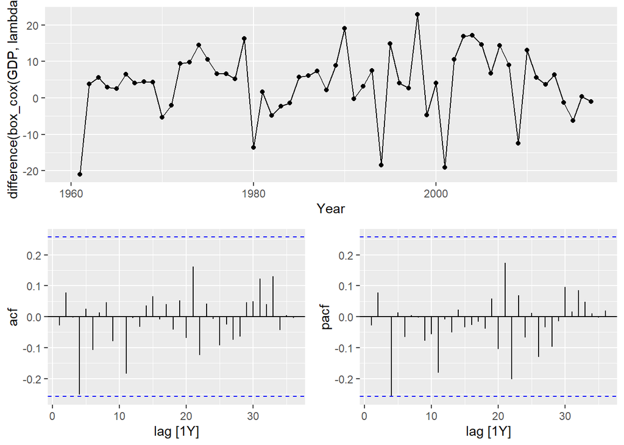

```r
## There is no seasonality in the data, just a general trend, performing one difference for the data. Seeing if second will be needed. Don't think it is, as the data now seems stationary. The top plot is white noise, and the ACF and PACF plots are within the proper critical value bounds.
print(turkey_economy |> gg_tsdisplay(difference(box_cox(GDP, lambda)),plot_type ="partial", lag=36))
```

#### b) Accommodation takings in the state of Tasmania from aus_accommodation.

```
## Plot variable not specified, automatically selected `.vars = Takings`
```

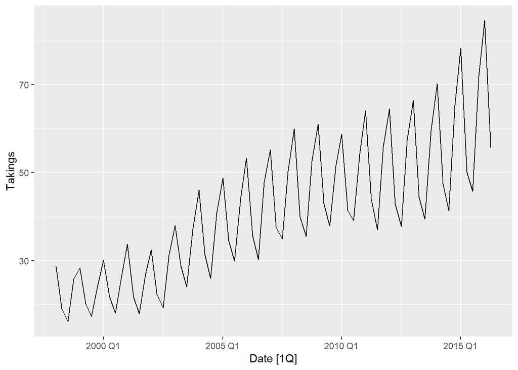

```r
tasmania <- aus_accommodation |> filter(State == 'Tasmania')
## Seasonality and trend in the data, needs to be smoothed out.
tasmania |> autoplot()
```

```r
## Performing the Box Cox transformation
lambda <- tasmania |>
  features(Takings, features = guerrero) |>
  pull(lambda_guerrero)
print(lambda) ## 0.0018 ## logging data is best.
```

```
## [1] 0.001819643
```

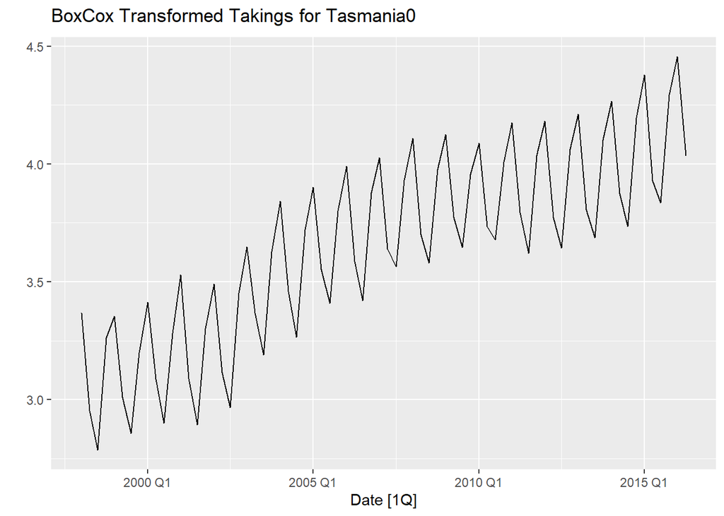

```r
## Box Cox Transform successful now to find the differentiation needs
print(tasmania |>  autoplot(box_cox(Takings, lambda)) +  labs(y = "",title = latex2exp::TeX(paste0("BoxCox Transformed Takings for Tasmania",round(lambda,2)))))
```

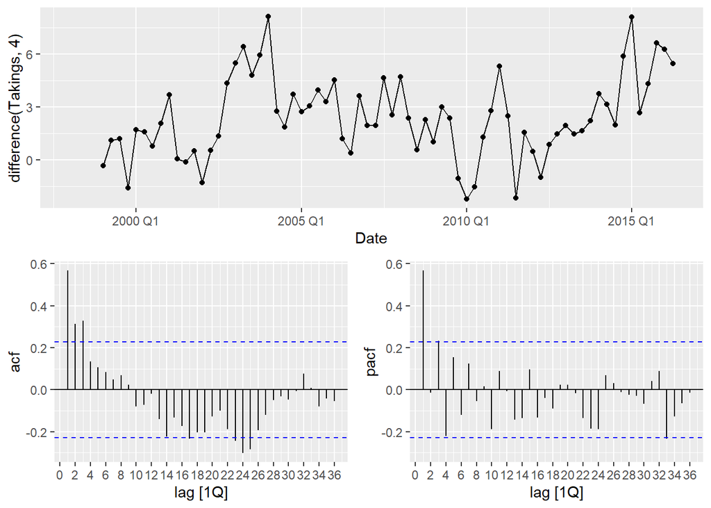

```r
## The seasonality is now constant(ish) and the trend looks better for differencing. In order to accommodate the seasonal nature of the data, we need to do a seasonal differencing. Doing a seasonal differencing of 4 because the data is quarterly.

print(tasmania |> gg_tsdisplay(difference(Takings,4), plot_type='partial', lag=36))
```

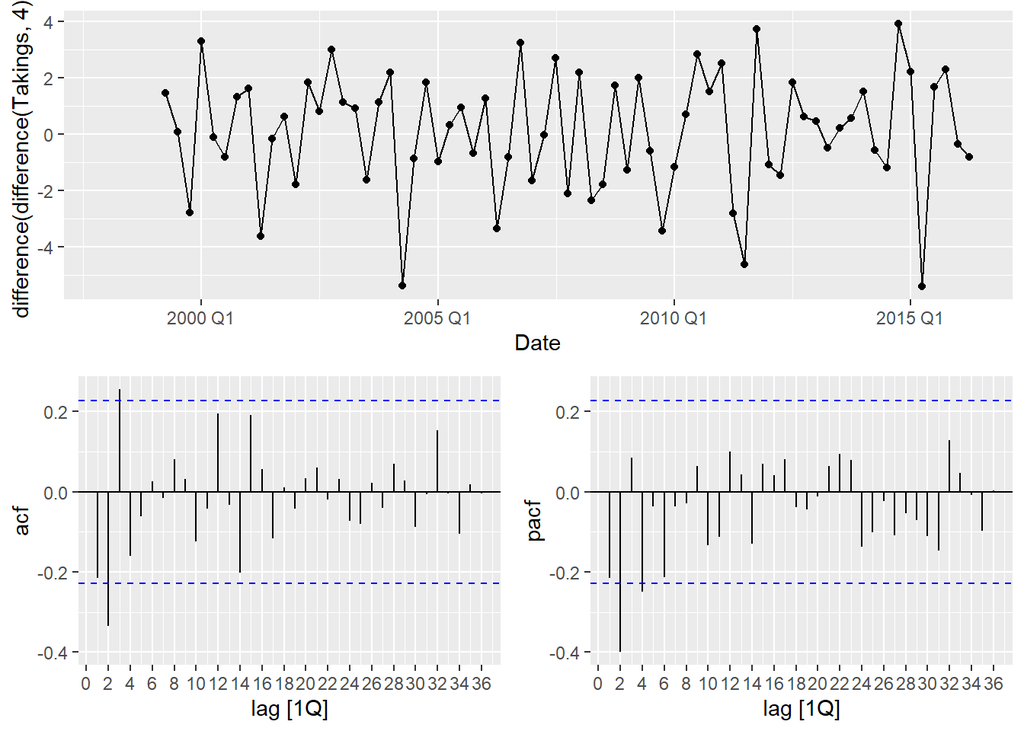

```r
## After looking at the data, it still does not seem completely stationary. The ACF has a trend, the PACF seems to have a slight one as well. There are also multiple values outside of the 95% confidence interval boundaries, so there needs to be a second differencing here.

print(tasmania |> gg_tsdisplay(difference(Takings,4)|> difference(), plot_type='partial', lag=36))
```

```r
## The data now looks much more like white noise, and is probably stationary now.
```

#### c) Monthly sales from souvenirs.

```
## Plot variable not specified, automatically selected `.vars = Sales`
```

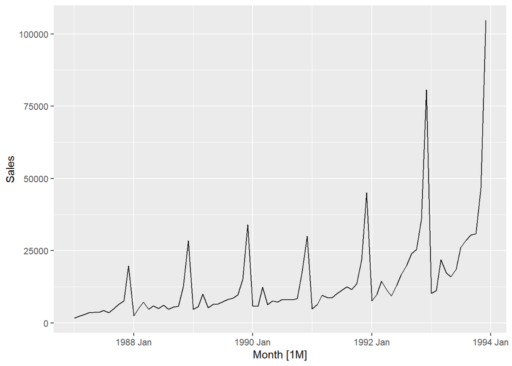

```r
## Taking a look at the data.
print(souvenirs |> autoplot())
```

```r
## There is both a trend and a seasonal pattern here. Using Box Cox to get proper transformation.
## Performing the Box Cox transformation
lambda <- souvenirs |>
  features(Sales, features = guerrero) |>
  pull(lambda_guerrero)
print(lambda) ## 0.00211 ## logging data is best.
```

```
## [1] 0.002118221
```

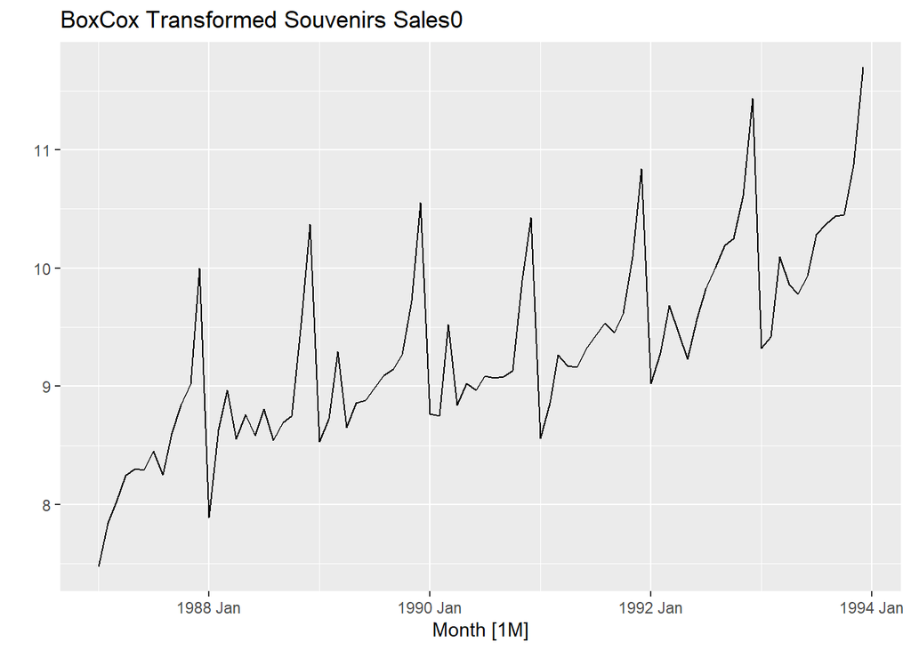

```r
## Box Cox Transform successful now to find the differentiation needs
print(souvenirs |>  autoplot(box_cox(Sales, lambda)) +  labs(y = "",title = latex2exp::TeX(paste0("BoxCox Transformed Souvenirs Sales",round(lambda,2)))))
```

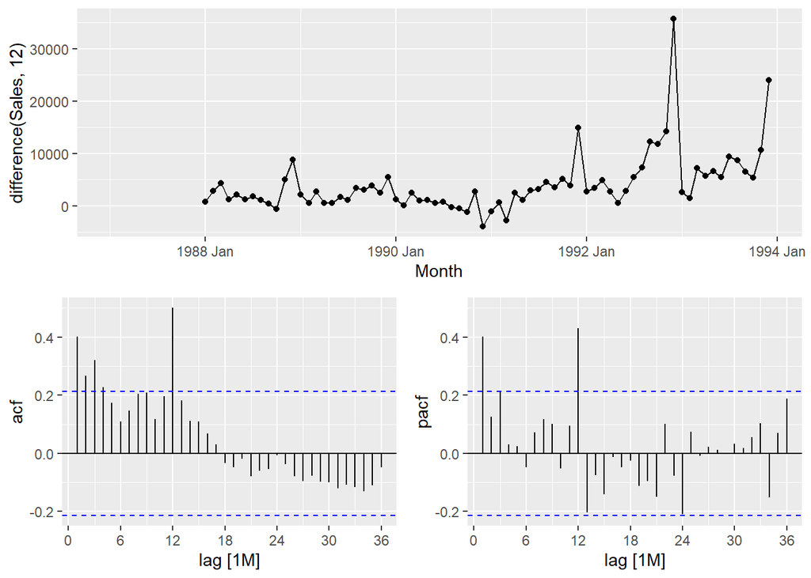

```r
## eveled out a bit, now doing differencing, monthly for seasonal. (12)
print(souvenirs |> gg_tsdisplay(difference(Sales,12), plot_type='partial', lag=36))
```

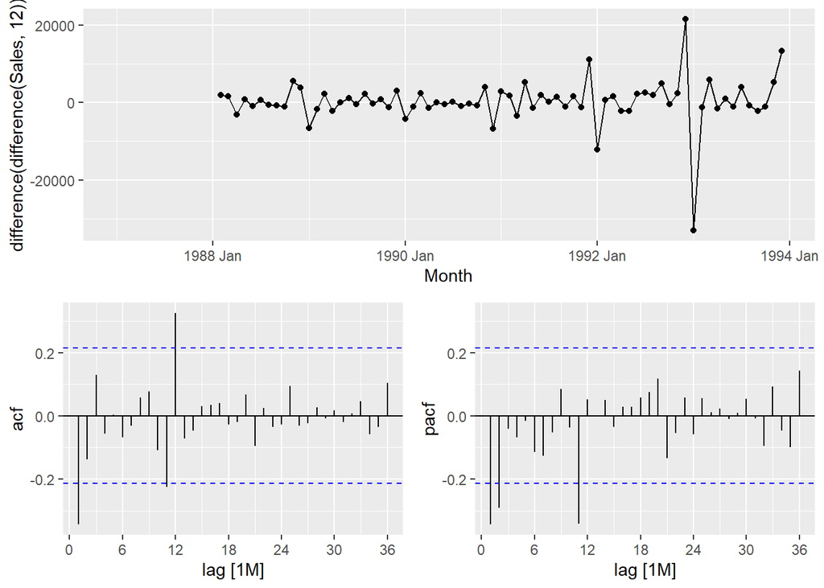

```r
## Still needs more differencing for the trend.
print(souvenirs |> gg_tsdisplay(difference(Sales,12) |> difference(), plot_type='partial', lag=36))
```

```r
## Data finally looks stationary, however there are multiple instances of outliers for the ACF and the PACF. Similar for the top chart too.
```